# Bed-2056 Exam

Asbjorn Aarekol & Morten Ostrem

12/7/2020

# Weapons and related data worldwide

Few topics are as heavily debated as firearms and how they should be regulated, particularly in the United States. Money talks, and with a market as large as that of firearms, it can be challenging to see through the propaganda on each side of the issue. In taking on this project, we took interest in the subject, wanting to get an unbiased view of how firearm availability correlates to things like homicide rates, individual economy and general happiness in a country. Following is our presentation of data taken from Kaggle, UNODC and Small Firearms Survey.

## Worldwide distribution of firearms

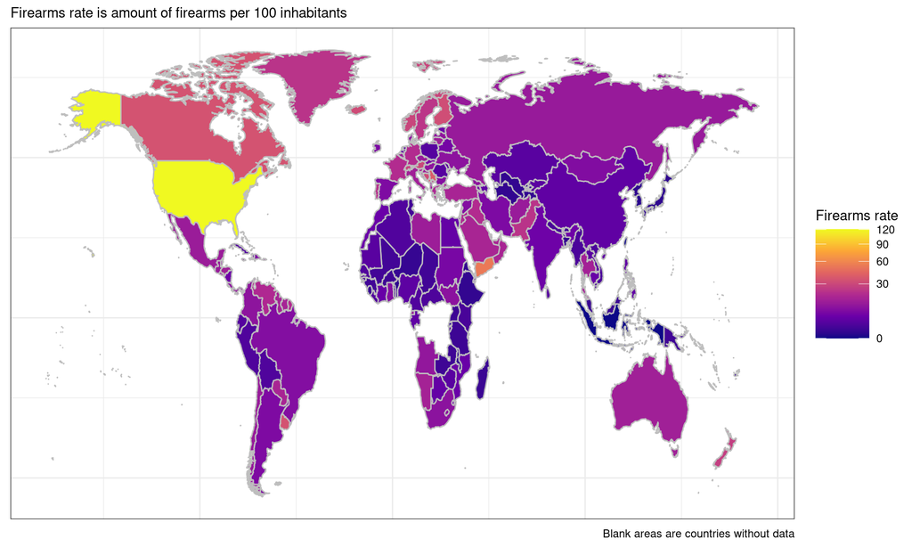

This plot shows the amount of firearms per 100 inhabitants in each country.

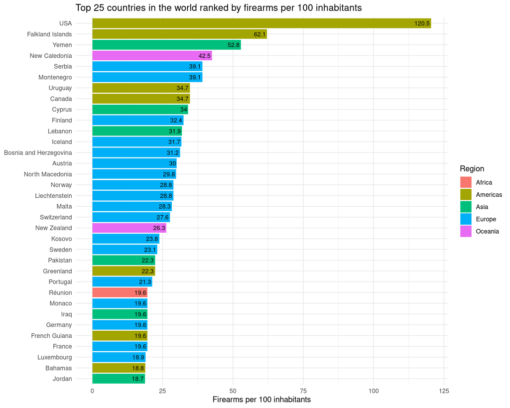

## Firearms prevalence and happiness

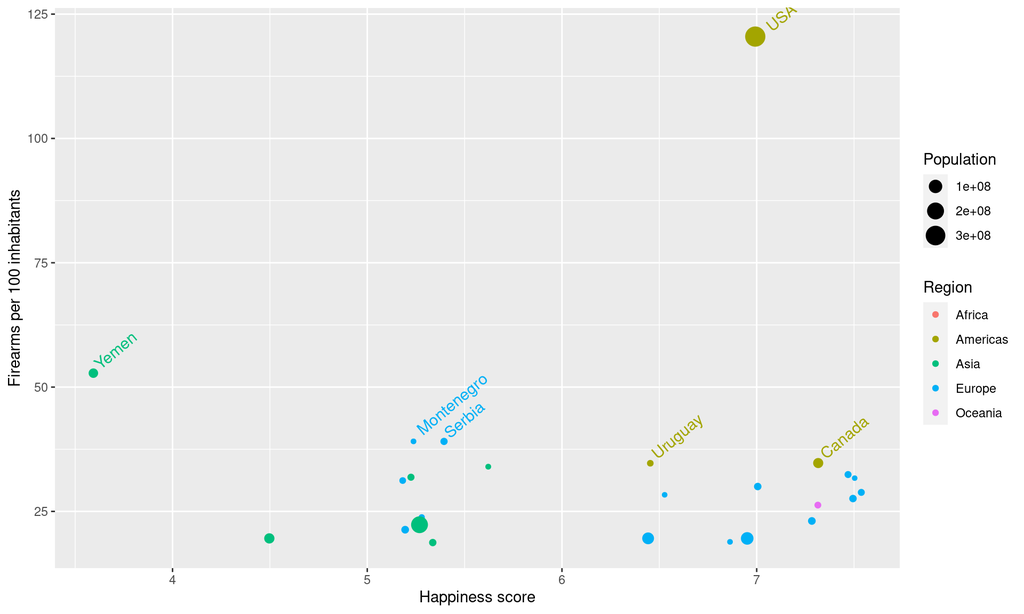

In the top 25 countries there does not seem to be a correlation with between firearms rate and happines. Thus we want to see if another metric is linked to firearms rate, such as GDP

## GDP vs firearms

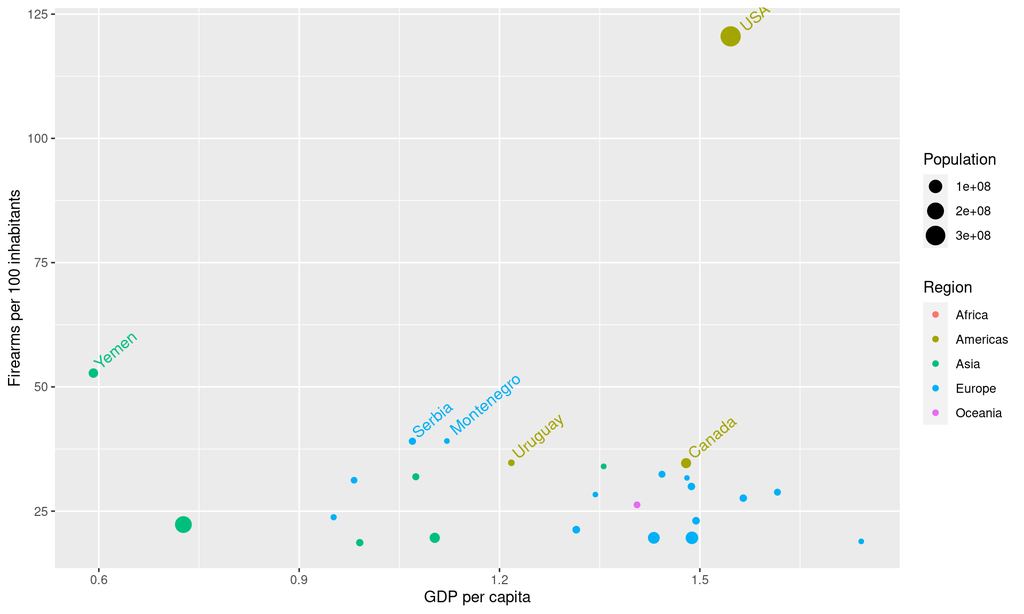

The GDP shows just as much interesting as the happines ranking. Our last metric from the world happines report is life expectancy

## Life expectancy vs firearms

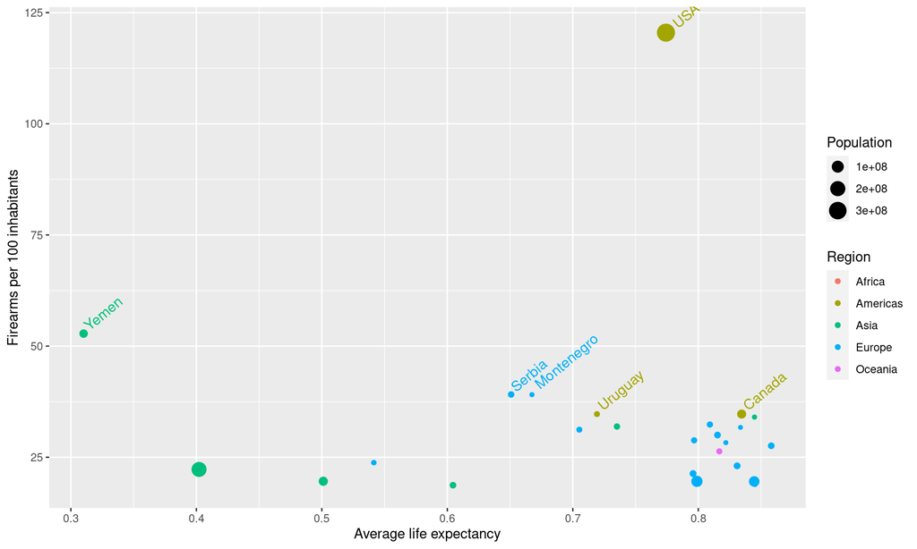

Life expectancy does aswell appear to not have any correlation with firearms rate. Given these results it shows that the answer to what affects gun ownership does not corelate to any of the metrics from the happines report. Seeing that a lot of the countries where in the same spot in the different graphs, we postulated that there might be a correlation between the metrics from the happines report.

## GDP vs Happiness

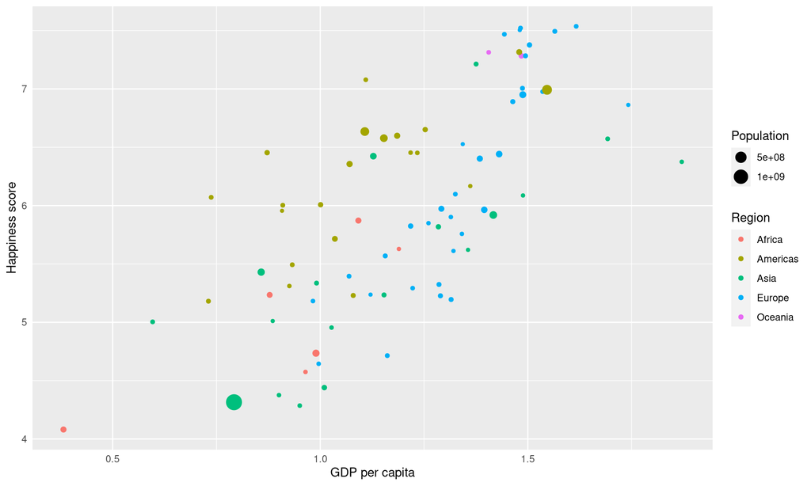

This graph shows that there might be a correlation between GDP and happines.

# A Change in outlook

Given that the data did not show anything else other than that there might not be a relation between these metrics, we want to change our outlook and look at homicide by firearms.

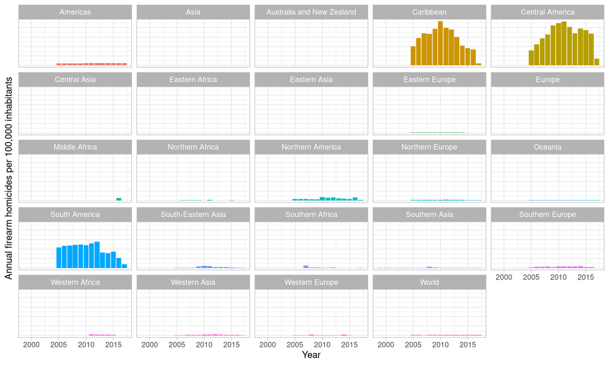

## Firearms homicide vs firearms per 100 inhabitants

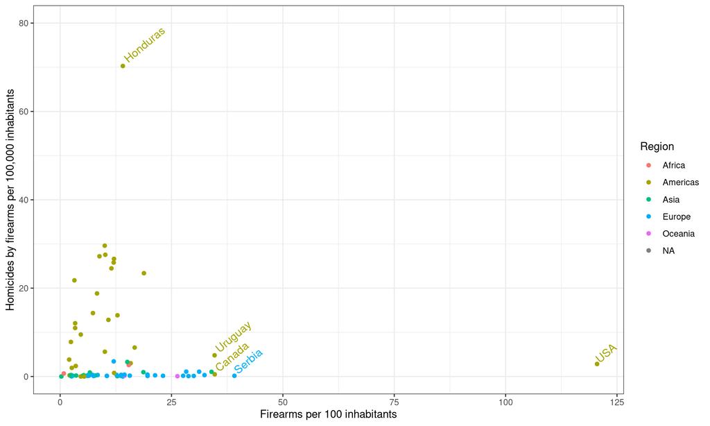

## Firearms rate vs total homicide rate

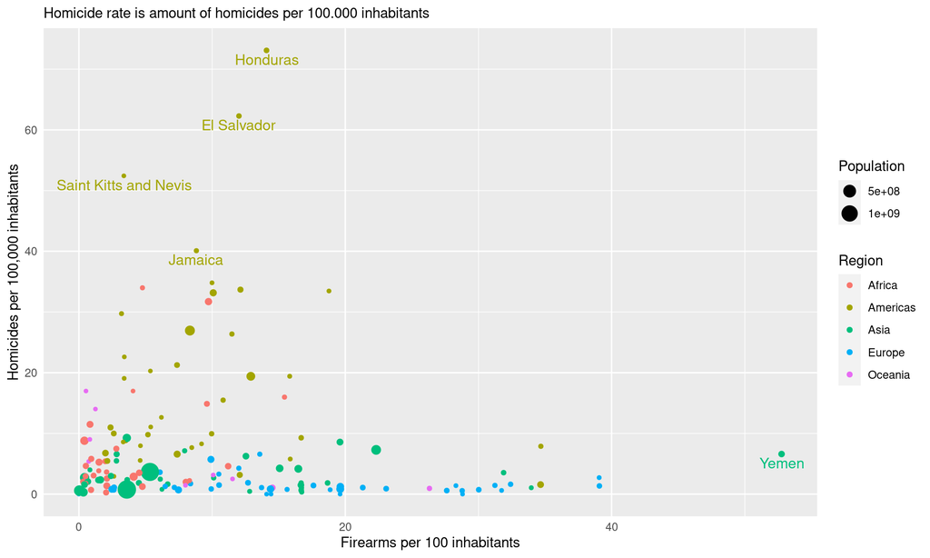

## Firearms rate vs firearms homicide rate

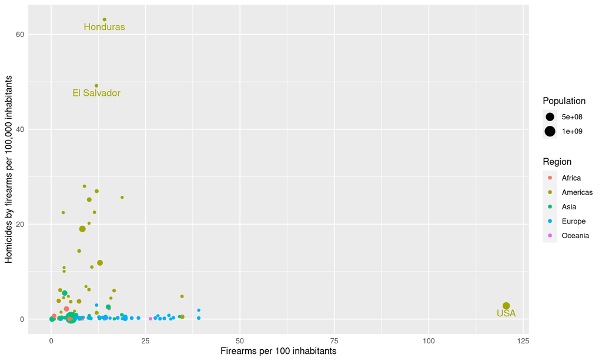

## Firearms rate vs proportion of homicides commited by firearms

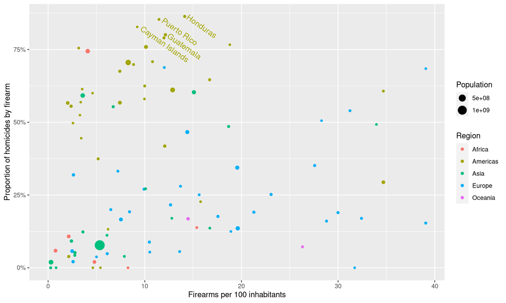

## Slice of happiness score and firearms homicide deathrate

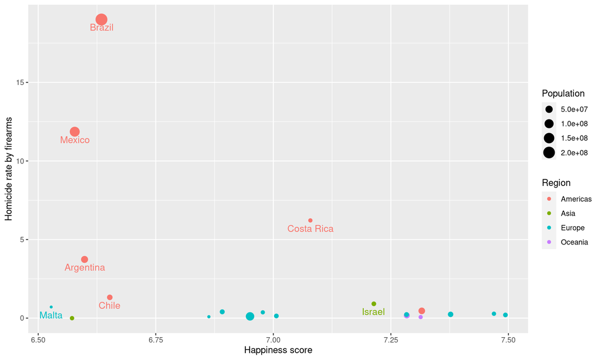